# Курсовая работа №1

## Аналитика

*Pandas, Matplotlib, Seaborn*  
**Описание работы:**

Определена бизнес-задача: на основании имеющихся данных подготовить аналитический отчёт, который в дальнейшем поможет продюсерам образовательных программ эффективно выстраивать стратегию по модернизированию и улучшению курсов.

**Содержание работы:**  
Codebook  
1. Описание и начальная работа с данными  
2. Расчёт потенциальной нагрузки на преподавателей  
3. Выявление проблемных модулей  
4. Расчёт конверсии  
5. Метрика успеваемости

## Codebook

`courses.csv` содержит следующие значения:  
`id` — идентификатор курса,  
`title` — название курса,  
`field` — сфера, к которой относится курс.  
`students.csv` содержит следующие значения:  
`id` — идентификатор студента,  
`city` — город студента,  
`birthday` — день рождения студента.  
`course_contents.csv` содержит следующие значения:  
`course_id` — идентификатор курса,  
`module_number` — номер модуля,  
`module_title` — название модуля,  
`lesson_number` — номер урока,  
`lesson_title` — название урока,  
`lesson_token` — токен урока,  
`is_video` — наличие видео *(true/false)*,  
`is_homework` — наличие домашней работы *(true/false)*.  
`progresses.csv` содержит следующие значения:  
`id` — идентификатор прогресса,  
`student_id` — идентификатор студента,  
`course_id` — идентификатор курса,  
`progress_phases.csv` содержит следующие значения:  
`progress_id` — идентификатор прогресса,  
`module_number` — номер модуля,  
`lesson_number` — номер урока,  
`status` — статус прохождения урока,  
`start_date` — дата начала,  
`finish_date` — дата окончания.

## 1. Описание и начальная работа с данными

### 0. Подготовка данных

```python
# импортируем необходимые библиотеки

import pandas as pd
import matplotlib.pyplot as plt
import seaborn as sns

# считаем данные из файлов

courses = pd.read_csv('courses.csv')
students = pd.read_csv('students.csv', parse_dates=['birthday'], dayfirst=False)
course_contents = pd.read_csv('course_contents.csv')
progresses = pd.read_csv('progresses.csv')
progress_phases = pd.read_csv('progress_phases.csv', parse_dates=['start_date', 'finish_date'], dayfirst=False)
```

```python
# объединим датасеты в 1

df = progress_phases.merge(progresses, how='left', left_on='progress_id', right_on='id')
df = df.drop(columns=['id'])
df = df.merge(courses, how='left', left_on='course_id', right_on='id')
df.drop(columns=['Unnamed: 0', 'id'], inplace=True)
df = df.merge(course_contents, how='left', on=['course_id', 'module_number', 'lesson_number'])
df
```

|  | progress_id | module_number | lesson_number | status | start_date | finish_date | student_id | course_id | title | field | module_title | lesson_title | lesson_token | is_video | is_homework |
| --- | --- | --- | --- | --- | --- | --- | --- | --- | --- | --- | --- | --- | --- | --- | --- |
| 0 | a387ab916f402cb3fbfffd29f68fd0ce | 2 | 4 | done | 2018-06-23 08:28:50.681065+00:00 | 2018-06-23 08:28:52.439542+00:00 | 768c2987a744c51ce64a5993a2a94eaf | c9fcb746d51e41bc5a217002d081454b | Веб-дизайн PRO 2.0 | Design | Концептуальный дизайн | Практика — мокапы | 7df8adef-1259-4b72-9bf2-353c73389d06 | True | False |
| 1 | a387ab916f402cb3fbfffd29f68fd0ce | 1 | 1 | done | 2018-06-20 14:25:21.783762+00:00 | 2018-06-20 15:45:07.717209+00:00 | 768c2987a744c51ce64a5993a2a94eaf | c9fcb746d51e41bc5a217002d081454b | Веб-дизайн PRO 2.0 | Design | Специализация и личное позиционирование | Интро курса | df1a1f20-cdf7-443d-b25b-0a4b990b84d9 | True | False |
| 2 | a387ab916f402cb3fbfffd29f68fd0ce | 2 | 2 | done | 2018-06-23 08:18:09.653771+00:00 | 2018-06-23 08:18:12.784616+00:00 | 768c2987a744c51ce64a5993a2a94eaf | c9fcb746d51e41bc5a217002d081454b | Веб-дизайн PRO 2.0 | Design | Концептуальный дизайн | Что такое концептуальный дизайн | f23b1890-9365-406f-816b-04864cefe58f | True | False |
| 3 | a387ab916f402cb3fbfffd29f68fd0ce | 1 | 4 | done | 2018-06-20 16:00:06.361780+00:00 | 2018-06-21 19:09:30.845034+00:00 | 768c2987a744c51ce64a5993a2a94eaf | c9fcb746d51e41bc5a217002d081454b | Веб-дизайн PRO 2.0 | Design | Специализация и личное позиционирование | Личное позиционирование | 9dd50916-4aa6-4a73-b86c-56a1bd7753c8 | True | False |
| 4 | a387ab916f402cb3fbfffd29f68fd0ce | 1 | 6 | done | 2018-06-21 19:10:36.957891+00:00 | 2018-06-28 15:59:25.320418+00:00 | 768c2987a744c51ce64a5993a2a94eaf | c9fcb746d51e41bc5a217002d081454b | Веб-дизайн PRO 2.0 | Design | Специализация и личное позиционирование | Домашняя работа | 43e1fbdd-1ee9-4ed5-a577-4dadd80c02b3 | False | True |
| ... | ... | ... | ... | ... | ... | ... | ... | ... | ... | ... | ... | ... | ... | ... | ... |
| 350672 | ea9c93865c1de54a5079b7ae71c88683 | 3 | 2 | start | 2019-07-16 23:02:33.482900+00:00 | NaT | 25ec58029696f8b7de38d22e5e01c7ea | bf27a4bf4ada4c756451703ea62a914f | Интернет-маркетолог от Ingate | Marketing | SEO: больше, чем поисковая выдача (обновление ... | Что такое SEO | 54905985-9222-493c-bebe-cbdf4c6535b1 | True | False |
| 350673 | ea9c93865c1de54a5079b7ae71c88683 | 2 | 4 | done | 2019-07-02 15:34:32.134806+00:00 | 2019-07-02 16:32:15.491277+00:00 | 25ec58029696f8b7de38d22e5e01c7ea | bf27a4bf4ada4c756451703ea62a914f | Интернет-маркетолог от Ingate | Marketing | Исследование целевой аудитории: портретировани... | Построение карты путей пользователя | dc58b42e-8440-4e08-9706-099b228fd534 | True | False |
| 350674 | ea9c93865c1de54a5079b7ae71c88683 | 2 | 3 | done | 2019-07-01 21:46:27.908354+00:00 | 2019-07-01 21:48:04.806799+00:00 | 25ec58029696f8b7de38d22e5e01c7ea | bf27a4bf4ada4c756451703ea62a914f | Интернет-маркетолог от Ingate | Marketing | Исследование целевой аудитории: портретировани... | Сбор данных | b19caa4b-bf5d-4db4-86fb-a65ffe63fc00 | True | False |
| 350675 | ea9c93865c1de54a5079b7ae71c88683 | 2 | 2 | done | 2019-06-30 22:41:33.705765+00:00 | 2019-07-01 07:44:00.370798+00:00 | 25ec58029696f8b7de38d22e5e01c7ea | bf27a4bf4ada4c756451703ea62a914f | Интернет-маркетолог от Ingate | Marketing | Исследование целевой аудитории: портретировани... | Сегментация ЦА и составление портрета клиента | d1ddacdc-797c-4115-afd4-31a05cda738d | True | False |
| 350676 | ea9c93865c1de54a5079b7ae71c88683 | 3 | 1 | done | 2019-07-14 23:36:52.318819+00:00 | 2019-07-15 12:21:47.908115+00:00 | 25ec58029696f8b7de38d22e5e01c7ea | bf27a4bf4ada4c756451703ea62a914f | Интернет-маркетолог от Ingate | Marketing | SEO: больше, чем поисковая выдача (обновление ... | Поисковые системы | 24a3760d-6e3f-4bf0-92d3-2cc3f3b0c781 | True | False |

350677 rows × 15 columns

### 1.1. Описание данных

A. общее количество курсов в датасете

```python
df['course_id'].nunique()
```

```
15
```

B. количество модулей на каждом курсе

```python
mod_num = df.groupby('course_id')['module_number'].nunique().reset_index()
mod_num['module_number'].describe()
```

```
count    15.000000
mean     15.266667
std       4.787882
min       8.000000
25%      10.000000
50%      17.000000
75%      18.500000
max      21.000000
Name: module_number, dtype: float64
```

C. количество уроков в каждом модуле на каждом курсе

```python
mod_les_num = df.groupby(['course_id', 'module_number'])['lesson_number'].nunique().reset_index()
mod_les_num['lesson_number'].describe()
```

```
count    229.000000
mean       5.240175
std        3.898825
min        1.000000
25%        2.000000
50%        5.000000
75%        7.000000
max       29.000000
Name: lesson_number, dtype: float64
```

D. медианное количество уроков в модуле на каждом курсе

```python
mod_les_num.groupby('course_id')['lesson_number'].median().reset_index()
```

|  | course_id | lesson_number |
| --- | --- | --- |
| 0 | 04ba6d0b40670c43a209141fa01fa784 | 3.0 |
| 1 | 0770b1b039964228294f1f34b29fc2c1 | 5.0 |
| 2 | 17013cd19d25cb3f28dc1b2683721bb9 | 3.0 |
| 3 | 480d25ad36878fce09e7aada316ba1a6 | 2.0 |
| 4 | 6e4837f0a65c68efbfdd0594d6774701 | 7.0 |
| 5 | 842218e7c983795934bbe4533c0888c8 | 6.0 |
| 6 | 943306102e5b067d08a29094f37b8193 | 13.0 |
| 7 | abce125a877c2196a3bc7bfbc11b5fc5 | 7.0 |
| 8 | ac634845fb0350d0e9d49078aaa4b68f | 5.0 |
| 9 | bf27a4bf4ada4c756451703ea62a914f | 6.5 |
| 10 | c9fcb746d51e41bc5a217002d081454b | 5.0 |
| 11 | ccbab00e99b27f83369d6cc89d914ad6 | 4.0 |
| 12 | dad6f6ffc086caa89e2f40c28a9c7490 | 3.5 |
| 13 | e3a0df907589d56692b5cb561fd90d87 | 4.0 |
| 14 | e9bb9205eeed307ee7cbaa08bfd166c3 | 7.0 |

E. количество учеников на каждом курсе

```python
student_quantity = df.groupby('title').agg({'student_id': lambda x: x.nunique()}).reset_index().sort_values(by='student_id', ascending=False)

# добавим столбец с сферой курсов
student_quantity = student_quantity.merge(df[['title', 'field']].drop_duplicates(), on='title', how='inner')
student_quantity.columns = ['course_name', 'students_count', 'field']
student_quantity
```

|  | course_name | students_count | field |
| --- | --- | --- | --- |
| 0 | Интернет-маркетолог от Ingate | 2168 | Marketing |
| 1 | Веб-дизайн с нуля 2.0 | 2014 | Design |
| 2 | Веб-вёрстка для начинающих 2.0 | 2004 | Development |
| 3 | Веб-дизайн PRO 2.0 | 1711 | Design |
| 4 | UX-дизайн | 1151 | Design |
| 5 | JavaScript с нуля | 966 | Development |
| 6 | PHP-разработчик с 0 до PRO. Часть 1 | 854 | Development |
| 7 | Excel Базовый | 782 | Business |
| 8 | Java-разработчик | 763 | Development |
| 9 | Руководитель digital-проектов | 685 | Business |
| 10 | Веб-разработчик | 628 | Development |
| 11 | Анимация интерфейсов | 598 | Design |
| 12 | Java-разработчик c нуля | 581 | Development |
| 13 | Веб-дизайн Базовый | 518 | Design |
| 14 | SMM-маркетолог от А до Я | 506 | Marketing |

F. минимальный, максимальный, средний, медианный возраст студентов;

```python
# определим сегодняшнюю дату
from datetime import datetime
today = datetime.today()

# отфильтруем NaN в столбце с датой рождения, а также те даты, год в которых начинается не на 19 и 20
students_birth = students[(~students.birthday.isna()) & (students.birthday.apply(lambda x: str(x).startswith(('19','20'))))][['id', 'birthday']]

# переведем столбец с датой рождения из строкового типа в datetime
students_birth['birthday'] = pd.to_datetime(students_birth['birthday'], yearfirst=True)
students_birth['age'] = students_birth['birthday'].apply(lambda x: (today.year - x.year - ((today.month, today.day) < (x.month, x.day))))

# добавим столбец с возрастом в датафрейм с данными студентов
students = students[['id_', 'id', 'city']].merge(students_birth, on='id', how='left')

# рассчитаем минимальный, максимальный, средний, медианный возраст студентов
students.describe()
```

|  | id_ | age |
| --- | --- | --- |
| count | 43830.000000 | 25485.000000 |
| mean | 74069.361921 | 32.135688 |
| std | 39371.624299 | 7.985283 |
| min | 1129.000000 | -59.000000 |
| 25% | 33446.250000 | 27.000000 |
| 50% | 96389.500000 | 32.000000 |
| 75% | 110909.500000 | 37.000000 |
| max | 124555.000000 | 123.000000 |

G. минимальный, максимальный, средний, медианный возраст студентов на каждом курсе.

```python
# отфильтруем неправдоподобные значения возраста и объединим датафрейм с даннми по прогрессам и курсам с возрастом студентов
med_age = df.merge(students[(students['age'] < 100) & (students['age'] > 10)], how='left', left_on='student_id', right_on='id').groupby('course_id')['age'].describe()

# добавим название курсов
med_age.merge(df[['course_id', 'title']].drop_duplicates(), how='left', on='course_id')
```

|  | course_id | count | mean | std | min | 25% | 50% | 75% | max | title |
| --- | --- | --- | --- | --- | --- | --- | --- | --- | --- | --- |
| 0 | 04ba6d0b40670c43a209141fa01fa784 | 5460.0 | 32.757875 | 5.524909 | 18.0 | 29.0 | 32.0 | 36.0 | 54.0 | Анимация интерфейсов |
| 1 | 0770b1b039964228294f1f34b29fc2c1 | 14789.0 | 34.805802 | 5.243246 | 21.0 | 32.0 | 34.0 | 38.0 | 58.0 | Руководитель digital-проектов |
| 2 | 17013cd19d25cb3f28dc1b2683721bb9 | 13735.0 | 31.486567 | 6.215930 | 19.0 | 27.0 | 31.0 | 35.0 | 54.0 | Веб-дизайн Базовый |
| 3 | 480d25ad36878fce09e7aada316ba1a6 | 4487.0 | 30.426789 | 6.149637 | 16.0 | 27.0 | 30.0 | 34.0 | 54.0 | Веб-разработчик |
| 4 | 6e4837f0a65c68efbfdd0594d6774701 | 22716.0 | 32.630129 | 7.910779 | 17.0 | 27.0 | 32.0 | 37.0 | 67.0 | Java-разработчик |
| 5 | 842218e7c983795934bbe4533c0888c8 | 7627.0 | 31.864167 | 6.098300 | 20.0 | 27.0 | 31.0 | 35.0 | 55.0 | SMM-маркетолог от А до Я |
| 6 | 943306102e5b067d08a29094f37b8193 | 14294.0 | 32.899608 | 7.487151 | 17.0 | 28.0 | 32.0 | 37.0 | 58.0 | Java-разработчик c нуля |
| 7 | abce125a877c2196a3bc7bfbc11b5fc5 | 28927.0 | 31.623639 | 6.886400 | 16.0 | 27.0 | 31.0 | 35.0 | 62.0 | Веб-вёрстка для начинающих 2.0 |
| 8 | ac634845fb0350d0e9d49078aaa4b68f | 17162.0 | 36.106281 | 6.977192 | 19.0 | 31.0 | 36.0 | 41.0 | 64.0 | Excel Базовый |
| 9 | bf27a4bf4ada4c756451703ea62a914f | 66878.0 | 34.370226 | 6.768763 | 19.0 | 30.0 | 33.0 | 38.0 | 93.0 | Интернет-маркетолог от Ingate |
| 10 | c9fcb746d51e41bc5a217002d081454b | 16813.0 | 31.416642 | 6.642553 | 18.0 | 27.0 | 30.0 | 35.0 | 62.0 | Веб-дизайн PRO 2.0 |
| 11 | ccbab00e99b27f83369d6cc89d914ad6 | 5840.0 | 34.019007 | 8.321681 | 16.0 | 29.0 | 33.0 | 38.0 | 78.0 | PHP-разработчик с 0 до PRO. Часть 1 |
| 12 | dad6f6ffc086caa89e2f40c28a9c7490 | 20944.0 | 33.336851 | 6.189261 | 18.0 | 29.0 | 33.0 | 36.0 | 88.0 | UX-дизайн |
| 13 | e3a0df907589d56692b5cb561fd90d87 | 71998.0 | 31.065752 | 6.616694 | 16.0 | 27.0 | 30.0 | 34.0 | 78.0 | Веб-дизайн с нуля 2.0 |
| 14 | e9bb9205eeed307ee7cbaa08bfd166c3 | 19333.0 | 31.494543 | 6.741060 | 16.0 | 27.0 | 31.0 | 36.0 | 62.0 | JavaScript с нуля |

### 1.2. Количество студентов на курсах

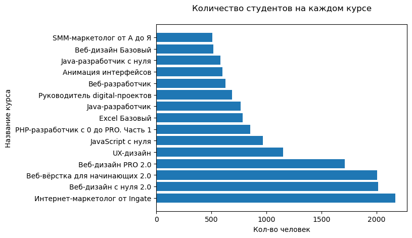

```python
plt.barh(student_quantity['course_name'], student_quantity['students_count'])
plt.title('Количество студентов на каждом курсе', y=1.05)
plt.xlabel('Кол-во человек')
plt.ylabel('Название курса')
plt.show()
```

### 1.3. Количество студентов на курсах по сферам

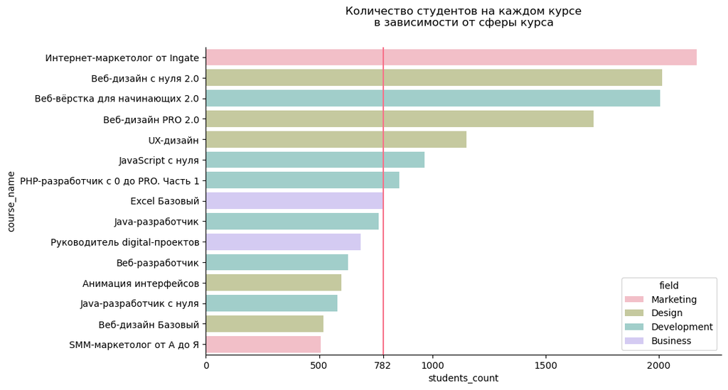

```python
fig, ax = plt.subplots(figsize=(10, 6))
sns.barplot(data=student_quantity, x='students_count', y='course_name', hue='field', palette='husl', alpha=0.5, ax=ax, dodge=False)
plt.title('Количество студентов на каждом курсе\nв зависимости от сферы курса', y=1.05)
ax.spines[['top', 'right']].set_visible(False)

med = student_quantity['students_count'].median()
ax.axvline(med, color=sns.color_palette('husl', 1)[0])
x_range = [0, 500, med, 1000, 1500, 2000]
plt.xticks(x_range)
plt.show()
```

### 1.4. Выводы по блоку

1. В датасете присутствует 15 курсов, в каждом из которых от 8 до 21 модуля (медианное значение - 17 модулей) и от 1 до 29 уроков в каждом модуле (медианное значение - 5 уроков в модуле)
2. На курсах обучается от 506 до 2168 человек. Топ-3 по численности обучающихся студентов являются курсы:Интернет-маркетолог от Ingate, Веб-дизайн с нуля 2.0, Веб-вёрстка для начинающих 2.0.
3. На курсах обучаются люди от 16 до 93 лет (если предположить, что значения более 100 и менее 10 малореалистичны). Медианный возраст обучающихся на различных курсах находится в диапазоне от 30 до 36 лет - самые молодые люди учатся на курсе Веб-дизайн с нуля 2.0, Веб-дизайн PRO 2.0, Веб-разработчик, , а с самым большим возрастом - на курсе Excel Базовый.
4. Явная зависимость между количеством студентов на курсе и сферой курса не выявлена - в каждой сфере есть как более посещаемые, так и менее посещаемые курсы, при этом как наиболее так и наименее многочисленный по ученикам курс относится к категории Marketing.

## 2. Расчет потенциальной нагрузки на преподавателей

### 2.1. Количество студентов в каждом месяце для каждого курса, которые начинали выполнение первой домашней работы в каждом месяце.

```python
# оставим только те модули и уроки, где есть дз, отсортируем по номеру модуля и урока и возьмем самое первое значение для каждого курса
first_hw = df[df['is_homework'] == True
             ].sort_values(by=['module_number', 'lesson_number']
                          ).groupby('title')[['module_number', 'lesson_number']
                                            ].agg(lambda x: x.iloc[0]).reset_index()

# переименуем колонки
first_hw.columns = ['title', 'first_hw_mod', 'first_hw_les']

#  добавим полученную колонку с первым модулем с дз в каждом курсе в изначальный датафрейм
df = df.merge(first_hw, how='left', on='title')
```

```python
# отфильтруем прогрессы по первым дз курсов, сгруппируем по году, месяцу и названию курса, посчитаем количество прогрессов
started_hw = df[(df['module_number'] == df['first_hw_mod']) & (df['lesson_number'] == df['first_hw_les'])
  ].groupby([df['start_date'].dt.year, df['start_date'].dt.month, df['title']])['student_id'].count().reset_index(allow_duplicates=True)

# переименуем столбцы
started_hw.columns = ['start_year', 'start_month', 'title', 'student_count']

# объединим год и месяц в одном столбце
started_hw['start_y_m'] = list(map(lambda x, y: f'{x}-{y}', started_hw['start_year'], started_hw['start_month']))

# уберем лишние колонки
started_hw.drop(columns=['start_month', 'start_year'], inplace=True)

# преобразуем столбец с годом и месяцем в тип datetime
started_hw['start_y_m'] = pd.to_datetime(started_hw['start_y_m'], format='%Y-%m')
started_hw
```

|  | title | student_count | start_y_m |
| --- | --- | --- | --- |
| 0 | Веб-разработчик | 1 | 2016-03-01 |
| 1 | UX-дизайн | 2 | 2016-11-01 |
| 2 | Веб-дизайн Базовый | 2 | 2017-03-01 |
| 3 | UX-дизайн | 1 | 2017-04-01 |
| 4 | Веб-разработчик | 1 | 2017-04-01 |
| ... | ... | ... | ... |
| 239 | Веб-дизайн Базовый | 2 | 2019-07-01 |
| 240 | Веб-дизайн с нуля 2.0 | 76 | 2019-07-01 |
| 241 | Веб-разработчик | 4 | 2019-07-01 |
| 242 | Интернет-маркетолог от Ingate | 91 | 2019-07-01 |
| 243 | Руководитель digital-проектов | 20 | 2019-07-01 |

244 rows × 3 columns

```python
# проверка
# df[(df['start_date'].dt.year == 2016) & (df['start_date'].dt.month == 3) & (df['title'] == 'Веб-разработчик')]
```

### 2.2. Line-graph с приростом студентов в каждом месяце для каждого курса

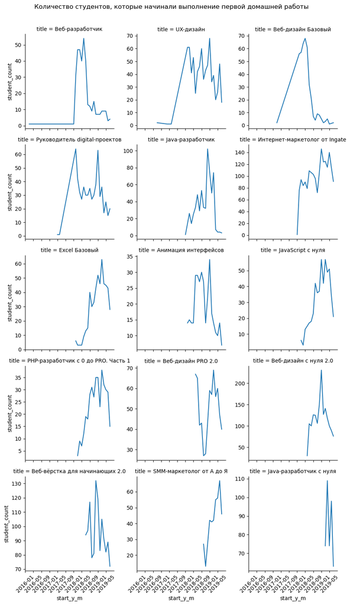

```python
g = sns.FacetGrid(started_hw, col='title', col_wrap=3, sharey=False)
g.map(sns.lineplot, 'start_y_m', 'student_count')
g.add_legend()

# повернем подписи на осях трех нижних графиков
for i, ax in enumerate(g.axes):
    if i in (12, 13, 14):
        ax.set_xticklabels(ax.get_xticklabels(), rotation=45)

plt.suptitle('Количество студентов, которые начинали выполнение первой домашней работы', y=1.03)
plt.show()
```